# Workshop II: Classification with Logistic Regression

Roopa Yashaswini Kotha

October 2024

# 1 Introduction

Welcome to the second workshop. We will continue working with the Lending Club data. In this workshop we will take the perspective of an investor to the lending club. Our goal is to select a subset of the most promising loans to invest in. We will do so using the method of logistic regression. Feel free to consult the RMD file of the session we had on logistic regression.

In answering the questions below be succinct but provide complete answers with quantitative evidence as far as possible. Feel free to discuss methods with each other and with the tutors during the workshop. As this is an individual assignment, *do not collaborate* in answering the questions below or in making investment choices.

*Please knit your RMD to an **HTML*** file. Please submit your *HTML* file **and** **CSV** file (for Q17). The deadline is 31st October 2024 at 11:59pm. 25% of your grade will depend on the performance of your investment choices (i.e., Q17). Please note that there is a 20% penalty on your individual assignment grade if you submit an RMD file.

Enjoy the workshop!

## 1.1 Load the data

First we need to start by loading the data.

```r
lc_raw <- read_csv("LendingClub Data.csv",  skip=1) %>%
  clean_names() # use janitor::clean_names()
```

# 2 ICE the data: Inspect, Clean, Explore

Any data science engagement starts with ICE. Inspecting, Clean and Explore the data.

## 2.1 Inspect the data

Inspect the data to understand what different variables mean. Variable definitions can be found in the excel version of the data.

```r
glimpse(lc_raw)
```

```
## Rows: 42,538
## Columns: 80
## $ int_rate            <dbl> 0.05, 0.05, 0.05, 0.05, 0.05, 0.05, 0.05, 0.05, 0.…
## $ loan_amnt           <dbl> 8000, 6000, 6500, 8000, 5500, 6000, 10200, 15000, …
## $ term_months         <dbl> 36, 36, 36, 36, 36, 36, 36, 36, 36, 36, 36, 36, 36…
## $ installment         <dbl> 241.28, 180.96, 196.04, 241.28, 165.88, 180.96, 30…
## $ dti                 <dbl> 2.11, 5.73, 17.68, 22.71, 5.75, 21.92, 18.62, 9.72…
## $ delinq_2yrs         <dbl> 0, 0, 0, 0, 0, 0, 0, 0, 0, 0, 0, 0, 0, 0, 0, 0, 0,…
## $ annual_inc          <dbl> 50000, 52800, 35352, 79200, 240000, 89000, 110000,…
## $ grade               <chr> "A", "A", "A", "A", "A", "A", "A", "A", "A", "A", …
## $ emp_title           <chr> NA, "coral graphics", NA, "Honeywell", "O T Plus, …
## $ emp_length          <chr> "5 years", "< 1 year", "n/a", "n/a", "10+ years", …
## $ home_ownership      <chr> "MORTGAGE", "MORTGAGE", "MORTGAGE", "MORTGAGE", "M…
## $ verification_status <chr> "Verified", "Source Verified", "Not Verified", "Ve…
## $ issue_d             <chr> "9/1/2011", "9/1/2011", "9/1/2011", "9/1/2011", "9…
```

[output cut: 67 more lines]

## 2.2 Clean the data

Are there any redundant columns and rows? Are all the variables in the correct format (e.g., numeric, factor, date)? Lets fix it.

The variable `loan_status` contains information as to whether the loan has been repaid or charged off (i.e., defaulted). Let’s create a binary factor variable for this. This variable will be the focus of this workshop.

```r
lc_clean<- lc_raw %>%
  select(-where(~ mean(is.na(.)) > 0.9)) %>% # drop columns with more than 90% missing data
  filter(!is.na(int_rate)) %>%   #delete empty rows
  mutate(
    issue_d = mdy(issue_d),  # lubridate::mdy() to fix date format
    term = factor(term_months),     # turn 'term' into a categorical variable
    delinq_2yrs = factor(delinq_2yrs) # turn 'delinq_2yrs' into a categorical variable
  ) %>%
  mutate(default = dplyr::recode(loan_status,
                      "Charged Off" = "1",
                      "Fully Paid" = "0"))%>%
    mutate(default = as.factor(default)) %>%
  dplyr::select(-emp_title,-installment, -term_months, everything()) #move some not-so-important variables to the end.
```

## 2.3 Explore the data **(Q1)**

Let’s explore loan defaults by creating different visualizations. We start with examining how prevalent defaults are, whether the default rate changes by loan grade or number of delinquencies, and a couple of scatter plots of defaults against loan amount and income.

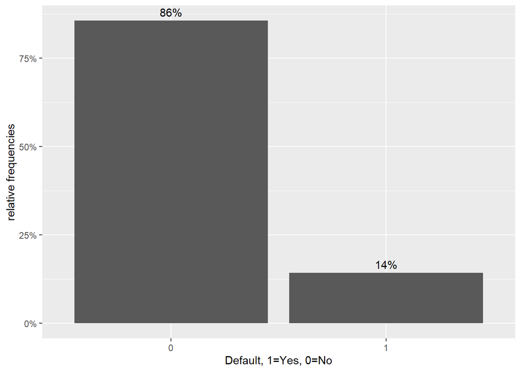

```r
#bar chart of defaults
def_vis1 <- ggplot(data=lc_clean, aes(x=default)) +
  geom_bar(aes(y = (..count..)/sum(..count..))) +
  labs(x="Default, 1=Yes, 0=No", y="relative frequencies") +
  scale_y_continuous(labels=scales::percent) +
  geom_text(aes( label = scales::percent((..count..)/sum(..count..) ),y=(..count..)/sum(..count..) ), stat= "count",vjust=-0.5)

def_vis1
```

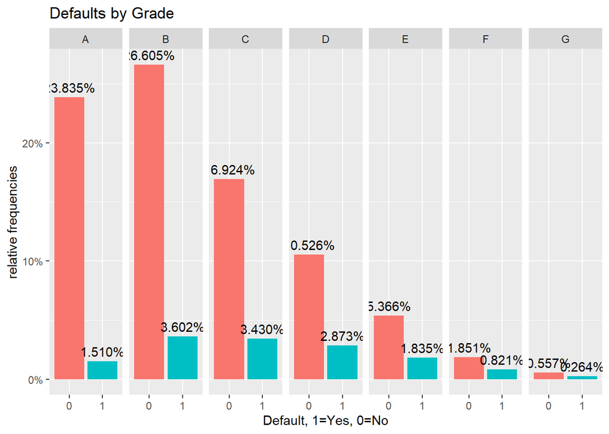

```r
#bar chart of defaults per loan grade
def_vis2 <- ggplot(data=lc_clean, aes(x=default), group=grade) +
  geom_bar(aes(y = (..count..)/sum(..count..), fill = factor(..x..)), stat="count")  +
  labs(title="Defaults by Grade", x="Default, 1=Yes, 0=No", y="relative frequencies")+
  scale_y_continuous(labels=scales::percent) +facet_grid(~grade) + theme(legend.position = "none") +
  geom_text(aes( label = scales::percent((..count..)/sum(..count..) ),y=(..count..)/sum(..count..) ), stat= "count",vjust=-0.5)
def_vis2
```

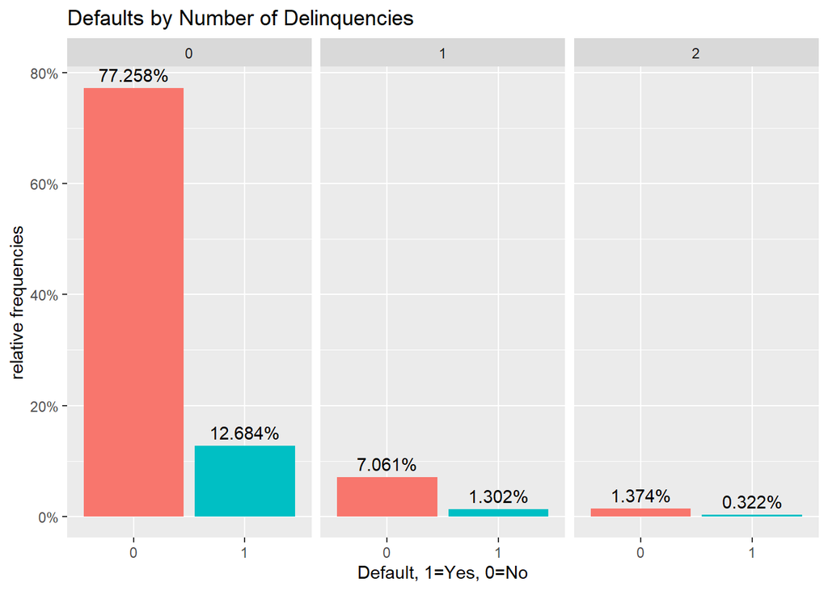

```r
#bar chart of defaults per number of Delinquencies
def_vis3 <- lc_clean %>%
  filter(as.numeric(delinq_2yrs)<4) %>%
  ggplot(aes(x=default), group=delinq_2yrs) +
  geom_bar(aes(y = (..count..)/sum(..count..), fill = factor(..x..)), stat="count")  +
  labs(title="Defaults by Number of Delinquencies", x="Default, 1=Yes, 0=No", y="relative frequencies")  +
  scale_y_continuous(labels=scales::percent) +facet_grid(~delinq_2yrs) + theme(legend.position = "none") +
  geom_text(aes( label = scales::percent((..count..)/sum(..count..) ),y=(..count..)/sum(..count..) ), stat= "count",vjust=-0.5)

def_vis3
```

[figure not shown]

```r
#scatter plots

#We select 2000 random loans to display only to make the display less busy.
set.seed(1234)
reduced<-lc_clean[sample(0:nrow(lc_clean), 2000, replace = FALSE),]%>%
  mutate(default=as.numeric(default)-1) # also convert default to a numeric {0,1} to make it easier to plot.


# scatter plot of defaults against loan amount
# If the jitter plot does not show up, try to remove I() and simply use x=loan_amnt/1000
def_vis4 <- ggplot(data=reduced, aes(y=default,x=I(loan_amnt/1000)))  +
  labs(y="Default, 1=Yes, 0=No", x="Loan Amnt (1000 $)") +
  geom_jitter(width=0, height=0.05, alpha=0.7) #We use jitter to offset the display of defaults/non-defaults to make the data easier to interpert. We have also changed the amount to 1000$ to reduce the number of zeros on the horizontal axis.

def_vis4
```

[figure not shown]

```r
#scatter plot of defaults against loan amount.
def_vis5 <- ggplot(data=reduced, aes(y=default,x=I(annual_inc/1000)))   + labs(y="Default, 1=Yes, 0=No", x="Annual Income(1000 $)") +geom_jitter(width=0, height=0.05, alpha=0.7) +  xlim(0,400)

def_vis5
```

We can also estimate a correlation table between defaults and other continuous variables.

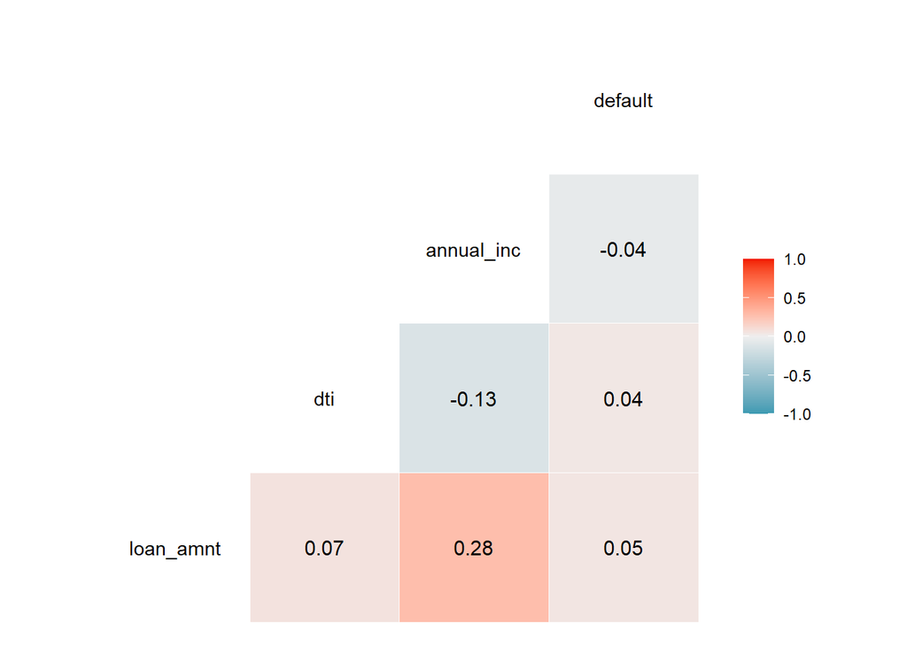

```r
# correlation table using GGally::ggcor()
# this takes a while to plot

lc_clean %>%
    mutate(default=as.numeric(default)-1)%>%
  select(loan_amnt, dti, annual_inc, default) %>% #keep Y variable last
 ggcorr(method = c("pairwise", "pearson"), label_round=2, label = TRUE)
```

> **Q1**. Add **one more** visualization of your own. Describe what it shows and what you learn from it in 1-2 lines.

Insert your code here:

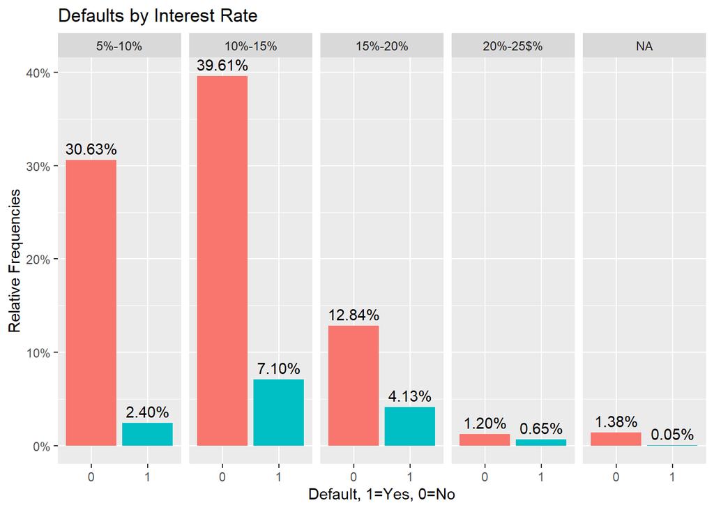

```r
# My visualization
# Load the data and define interest rate groups
lc_clean %>%
  mutate(
    # Create a new variable 'int_group' that categorizes 'int_rate' into ranges
    int_group = cut(int_rate, breaks = c(0.05, 0.10, 0.15, 0.20, 0.25),
                    labels = c("5%-10%", "10%-15%", "15%-20%", "20%-25$%"))
  ) %>%
  # Start ggplot with 'default' on x-axis, grouping by 'int_group'
  ggplot(aes(x = default), group = int_group) +

  # Create a bar plot showing the proportion of defaults within each group
  geom_bar(aes(y = (..count..) / sum(..count..), fill = factor(..x..)), stat = "count")  +

  # Add labels and title for the plot
  labs(
    title = "Defaults by Interest Rate",
    x = "Default, 1=Yes, 0=No",
    y = "Relative Frequencies"
  )  +

  # Convert y-axis values to percentages for easier interpretation
  scale_y_continuous(labels = scales::percent) +

  # Create separate panels (facets) for each 'int_group' category
  facet_grid(~int_group) +

  # Remove the legend for a cleaner look
  theme(legend.position = "none") +

  # Display percentage labels on top of each bar
  geom_text(
    aes(label = scales::percent((..count..) / sum(..count..)),
        y = (..count..) / sum(..count..)),
    stat = "count",
    vjust = -0.5
  )
```

The above visualisation provides a bar chart on the percentage of defaults based on the interest rates where the interest rates are grouped with an interval of 5%. From the above chart, maximum people were lent loans with interest rate of 10-15% and has the highest defaults as well.

# 3 Linear vs. logistic regression for binary response variables **(Q2)**

It is certainly possible to use the OLS approach to find the line that minimizes the sum of squared errors when the dependent variable is binary (i.e., default / no default). In this case, the predicted values take the interpretation of a probability. We can also estimate a logistic regression instead. We do both below.

```r
model_lm<-lm(as.numeric(default)~I(annual_inc/1000), lc_clean)
summary(model_lm)
```

```
##
## Call:
## lm(formula = as.numeric(default) ~ I(annual_inc/1000), data = lc_clean)
##
## Residuals:
##     Min      1Q  Median      3Q     Max
## -0.1595 -0.1494 -0.1444 -0.1332  1.3268
##
## Coefficients:
##                      Estimate Std. Error t value Pr(>|t|)
## (Intercept)         1.161e+00  2.703e-03 429.312   <2e-16 ***
## I(annual_inc/1000) -2.479e-04  2.918e-05  -8.496   <2e-16 ***
## ---
## Signif. codes:  0 '***' 0.001 '**' 0.01 '*' 0.05 '.' 0.1 ' ' 1
##
## Residual standard error: 0.3501 on 37867 degrees of freedom
## Multiple R-squared:  0.001903,   Adjusted R-squared:  0.001876
## F-statistic: 72.19 on 1 and 37867 DF,  p-value: < 2.2e-16
```

```r
logistic1<-glm(default~I(annual_inc/1000), family="binomial", lc_clean)
summary(logistic1)
```

```
##
## Call:
## glm(formula = default ~ I(annual_inc/1000), family = "binomial",
##     data = lc_clean)
##
## Coefficients:
##                      Estimate Std. Error z value Pr(>|z|)
## (Intercept)        -1.5191545  0.0292430  -51.95   <2e-16 ***
## I(annual_inc/1000) -0.0040801  0.0003998  -10.21   <2e-16 ***
## ---
## Signif. codes:  0 '***' 0.001 '**' 0.01 '*' 0.05 '.' 0.1 ' ' 1
##
## (Dispersion parameter for binomial family taken to be 1)
##
##     Null deviance: 31130  on 37868  degrees of freedom
## Residual deviance: 31005  on 37867  degrees of freedom
## AIC: 31009
##
## Number of Fisher Scoring iterations: 5
```

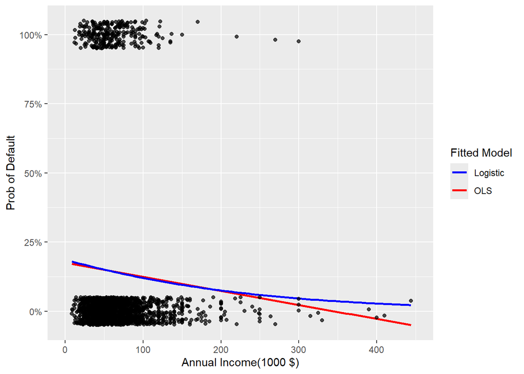

```r
ggplot(data=reduced, aes(x=annual_inc/1000, y=default)) +
  geom_smooth(method="lm", se=0, aes(color="OLS"))+
  geom_smooth(method = "glm", method.args = list(family = "binomial"),  se=0, aes(color="Logistic"))+
  labs(y="Prob of Default", x="Annual Income(1000 $)")+
  xlim(0,450)+scale_y_continuous(labels=scales::percent)+geom_jitter(width=0, height=0.05, alpha=0.7) +
  scale_colour_manual(name="Fitted Model", values=c("blue", "red"))
```

> **Q2**. Which model is more suitable for predicting probability of default, the linear regression or the logistic? Why?

Answer here: Logistic regression is better model because linear regression is useful for predicting values and can predict probabilities less than 0 or higher than 1 which is not correct. In the graph above, the linear model line goes below 0%. However, the logistic regression predicts the probabilities in correct range, making it easier to classify.

# 4 Multivariate logistic regression **(Q3, Q4)**

We can estimate logistic regression with multiple explanatory variables as well. Let’s use `annual_inc`, `term`, `grade`, and `loan_amnt` as features. Let’s call this model `logistic2`.

```r
logistic2<- glm(default~annual_inc + term + grade + loan_amnt, family="binomial", lc_clean)
summary(logistic2)
```

```
##
## Call:
## glm(formula = default ~ annual_inc + term + grade + loan_amnt,
##     family = "binomial", data = lc_clean)
##
## Coefficients:
##               Estimate Std. Error z value Pr(>|z|)
## (Intercept) -2.432e+00  5.056e-02 -48.093   <2e-16 ***
## annual_inc  -6.019e-06  4.727e-07 -12.733   <2e-16 ***
## term60       4.790e-01  3.561e-02  13.451   <2e-16 ***
## gradeB       6.599e-01  5.270e-02  12.521   <2e-16 ***
## gradeC       1.031e+00  5.392e-02  19.128   <2e-16 ***
## gradeD       1.288e+00  5.703e-02  22.578   <2e-16 ***
## gradeE       1.415e+00  6.662e-02  21.241   <2e-16 ***
## gradeF       1.666e+00  8.630e-02  19.302   <2e-16 ***
## gradeG       1.769e+00  1.340e-01  13.198   <2e-16 ***
## loan_amnt    2.841e-06  2.347e-06   1.211    0.226
## ---
## Signif. codes:  0 '***' 0.001 '**' 0.01 '*' 0.05 '.' 0.1 ' ' 1
##
## (Dispersion parameter for binomial family taken to be 1)
##
##     Null deviance: 31130  on 37868  degrees of freedom
## Residual deviance: 29286  on 37859  degrees of freedom
## AIC: 29306
##
## Number of Fisher Scoring iterations: 5
```

```r
#compare the fit of logistic 1 and logistic 2
anova(logistic1,logistic2)
```

| Resid. Df | Resid. Dev | Df | Deviance | Pr(>Chi) |
| --- | --- | --- | --- | --- |
| 3.79e+04 | 3.1e+04 |  |  |  |
| 3.79e+04 | 2.93e+04 | 8 | 1.72e+03 | 0 |

> **Q3**. Based on logistic 2, explain the following:  
> a. Explain briefly the logic of MLE (maximum likelihood estimation).  
> b. What does the standard error of a coefficient mean?  
> c. What does the p-value of a coefficient mean?  
> d. What does deviance mean?  
> e. What does AIC mean?  
> f. What does null deviance mean?  
> g. Is Logistic 2 a better model than logistic 1? Why or why not?

Answer here:  
a. **Likelihood** determines the possibility of the predicting the correct outcome given the model parameters. Maximum likelihood estimation is a method to maximise this likelihood by adjusting the co-efficients of the model.

b. The **standard error of the coefficient** determines how precisely the model estimates the effect of an independent variable on the dependent variable

c. The **p-value** of the co-efficient tells the significance of the co-efficient (independent variable) on determining the dependent variable

d. **Deviance** measures the deviation of predicted results from actual data.

e. **AIC** is similar to deviance but it penalises for the number of co-efficients.

f. **Null-Deviance** means the deviation in predicted results when no co-efficients are considered but only the intercept. It acts as a base for comparing deviances.

> **Q4**. Calculate the predicted probabilities associated with logistic 2 and plot them as a density chart. Also plot the density of the predictions for those loans that did default, and for the loans that did not (on the same chart).

Insert your code here:

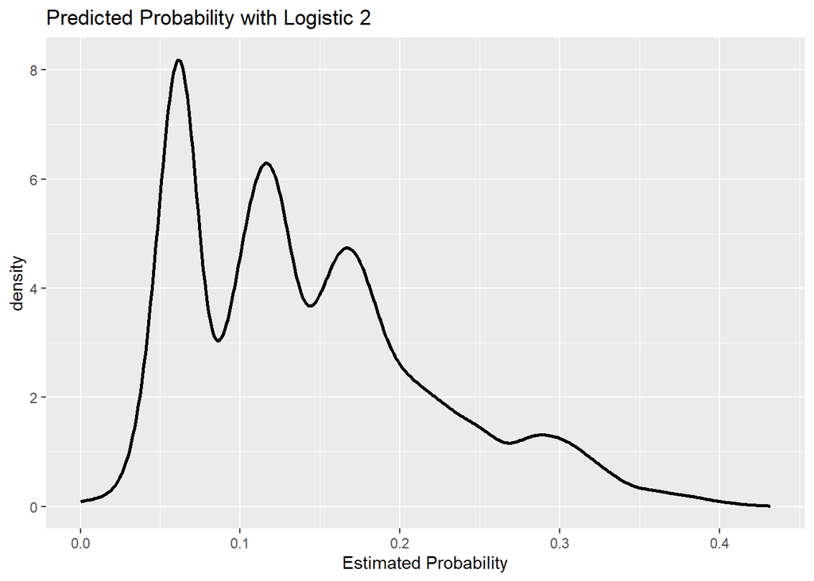

```r
#Predict the probability of default
prob_default<-predict(logistic2,lc_clean,type="response")

#plot 1: Density of predictions
g0<-ggplot( lc_clean, aes( prob_default ) )+
  geom_density( size=1)+
  ggtitle( "Predicted Probability with Logistic 2" )+
  xlab("Estimated Probability")
g0
```

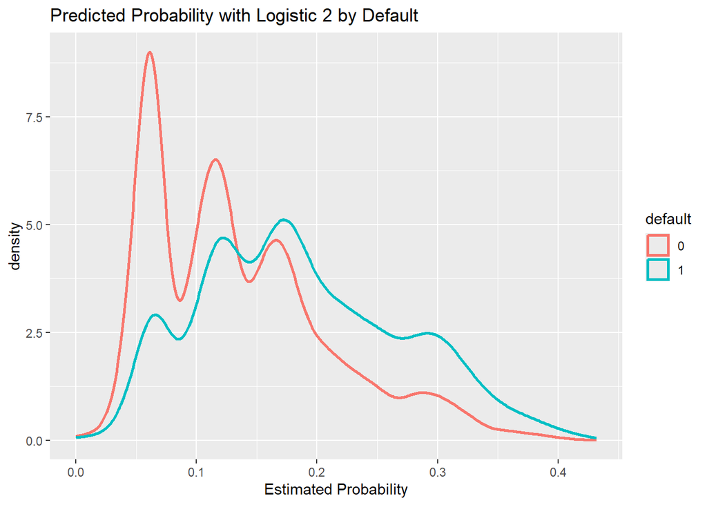

```r
#plot 2: Density of predictions by default
g1<-ggplot( lc_clean, aes( prob_default, color=default) ) +
  geom_density( size=1)+
  ggtitle( "Predicted Probability with Logistic 2 by Default" )+
  xlab("Estimated Probability")
g1
```

## 4.1 From probability to classification **(Q5-Q10)**

The logistic regression model gives us a sense of how likely defaults are; it gives us a probability estimate. To convert this into a prediction, we need to choose a cutoff probability and classify every loan with a predicted probability of default above the cutoff as a prediction of default (and vice versa for loans with a predicted probability below this cutoff).

Let’s choose a threshold of 16%. Of course some of our predictions will turn out to be right but some will turn out to be wrong – you can see this in the density figures of the previous section. Let’s call “default” the “positive” class since this is the class we are trying to predict. We could be making two types of mistakes. False positives (*i.e.,* predict that a loan will default when it will not) and false negatives (*i.e.,* predict that a loan will not default when it does). These errors are summarized in the confusion matrix.

> **Q5**. Produce the confusion matrix for the model logistic 2 for a cutoff of 16%

Insert your code here:

```r
#using the logistic 2 model predict default probabilities
prob_default2<- predict(logistic2,lc_clean,type="response")

#Call any loan with probability more than 16% as default and any loan with lower probability as non-default. Make sure your prediction is a factor with the same levels as the default variable in the lc_clean data frame
p_class<- ifelse(prob_default2 >= 0.16, "1", "0")

#produce the confusion matrix and set default as the positive outcome
con2<- confusionMatrix(as.factor(p_class), as.factor(lc_clean$default), positive="1")

#print the confusion matrix
con2
```

```
## Confusion Matrix and Statistics
##
##           Reference
## Prediction     0     1
##          0 21603  2204
##          1 10837  3225
##
##                Accuracy : 0.6556
##                  95% CI : (0.6508, 0.6604)
##     No Information Rate : 0.8566
##     P-Value [Acc > NIR] : 1
##
##                   Kappa : 0.1564
##
##  Mcnemar's Test P-Value : <2e-16
##
##             Sensitivity : 0.59403
##             Specificity : 0.66594
##          Pos Pred Value : 0.22934
##          Neg Pred Value : 0.90742
##              Prevalence : 0.14336
##          Detection Rate : 0.08516
##    Detection Prevalence : 0.37133
##       Balanced Accuracy : 0.62998
##
##        'Positive' Class : 1
##
```

> **Q6**. Using the confusion matrix, explain the following and show how they are calculated **a.1**. Accuracy **a.2.** Sensitivity **a.3.** Specificity For each of this explain what they mean in the context of the lending club and the goal of predicting loan defaults.

> **b.** Moreover, compare each of these three statistics with the two extreme models: the models that predict that every instance is “no default”/“default”.

Answer here:

a.1. Accuracy = Total correct predictions / Total predictions = (TP+TN)/(TP+TN+FP+FN)

a.2. Sensitivity = True Positives / (True Positives + False Negatives) = TP/(TP+FN)

a.3. Specificity = True Negatives / (True Negatives + False Positives) = TN/(TN+FP)

b. No Default Model: Accuracy = 85.66%, Sensitivity = 0, Specificity = 1

Default Model: Accuracy = 14.34%, Sensitivity = 1, Specificity = 0

> **Q7**. Repeat Q5 & Q6.a for the cutoff being 20%. Interpret the results. Is this cutoff a better choice? In the context of lending club, explain in what situation one might be interested in a high cutoff.

```r
p_class_updated<- ifelse(prob_default2 >= 0.20, "1", "0") # insert your code

#produce the confusion matrix and set default as the positive outcome
con2_updated<- confusionMatrix(as.factor(p_class_updated), as.factor(lc_clean$default), positive="1") # insert your code

#print the confusion matrix
con2_updated
```

```
## Confusion Matrix and Statistics
##
##           Reference
## Prediction     0     1
##          0 26580  3300
##          1  5860  2129
##
##                Accuracy : 0.7581
##                  95% CI : (0.7538, 0.7624)
##     No Information Rate : 0.8566
##     P-Value [Acc > NIR] : 1
##
##                   Kappa : 0.1768
##
##  Mcnemar's Test P-Value : <2e-16
##
##             Sensitivity : 0.39215
##             Specificity : 0.81936
##          Pos Pred Value : 0.26649
##          Neg Pred Value : 0.88956
##              Prevalence : 0.14336
##          Detection Rate : 0.05622
##    Detection Prevalence : 0.21096
##       Balanced Accuracy : 0.60576
##
##        'Positive' Class : 1
##
```

Provide comments here: 20% cutoff has higher accuracy and low sensitivity. However, in the case of lending club, since predicting defaults is very important, 16% cutoff which provides higher sensitivity is better.

> **Q8**. Previously, we compared the performance of the `logistic2` model with different cutoff values (16% and 20%). Recall that the concept of ROC curves roughly lets us do this analysis for more cutoff values. Using the model `logistic2` produce the ROC curve and calculate the AUC measure. Explain what the ROC shows and what the AUC measure means. Why do we expect the AUC of any predictive model to be between 0.5 and 1? Could the AUC ever be below 0.5 or above 1?

Insert your code here:

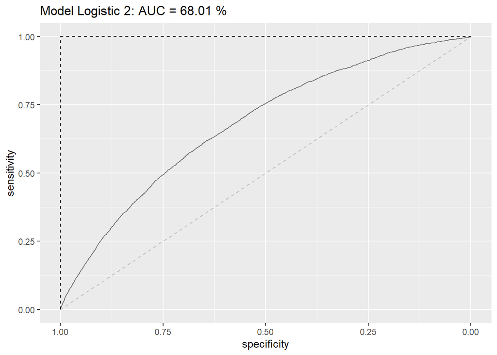

```r
# Calculate the ROC curve for 'logistic2' model
# 'roc' function takes the actual default outcomes and predicted probabilities of default (prob_default2)
ROC_logistic2 <- roc(lc_clean$default, prob_default2)
# Estimate the Area Under the Curve (AUC) for the 'logistic2' model
# Extract the AUC from the ROC object and store it in 'AUC2'
AUC2 <- ROC_logistic2$auc

# Plot the ROC curve with the ggroc function and display the AUC in the plot title
ggroc(ROC_logistic2, alpha = 0.5) +

  # Add a title to the plot, embedding the AUC value rounded to two decimal places
  ggtitle(paste("Model Logistic 2: AUC =", round(AUC2 * 100, digits = 2), "%"))  +

  # Add a dashed diagonal line representing a random classifier (where TPR = FPR)
  geom_segment(aes(x = 1, xend = 0, y = 0, yend = 1), color = "grey", linetype = "dashed") +

  # Add dashed segments for the x and y-axis extremes (TPR = 1 and FPR = 1) for clearer reference
  geom_segment(aes(x = 1, xend = 1, y = 0, yend = 1), color = "black", linetype = "dashed") +
  geom_segment(aes(x = 1, xend = 0, y = 1, yend = 1), color = "black", linetype = "dashed")
```

Provide comments here:

i. **ROC:** It plots the Sensitivity against Specificity for different thresholds.

ii. **AUC:** It indicates the area under the ROC curve which quantifies the overall performance of the model.

iii. If the AUC is 0.5, the model is clearly performing random guessing. Any record has an equal probability to be Yes or No similar to coin toss. As the AUC approaches to 1, the classifier is performing better. AUC = 1 indicates the perfect model for classification.

iv. If the AUC is less than 0.5, the model is worse than a random guessing model.

> **Q9**. So far we have only worked in-sample. Split the data into training and testing and estimate the models ROC curve and AUC measure out of sample. Is there any evidence of overfitting?

Insert your code here:

```r
# splitting the data into training and testing
set.seed(24)
train_test_split <- initial_split(lc_clean, prop = 0.8)
testing <- testing(train_test_split) #20% of the data is set aside for testing
training <- training(train_test_split) #80% of the data is set aside for training

# run logistic 2 on the training set
logistic2<- glm(default~annual_inc + term + grade + loan_amnt, family="binomial", training)            # insert your code
```

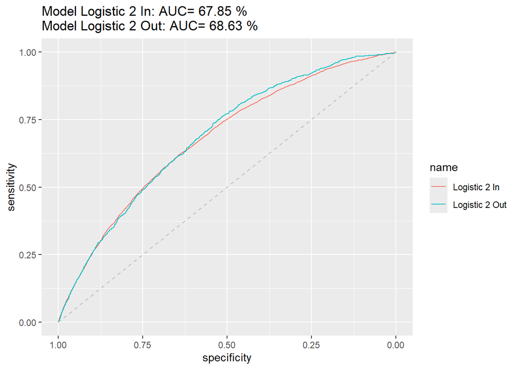

```r
#calculate probability of default in the training sample
p_in<- predict(logistic2, training, type="response")

#ROC curve using in-sample predictions
ROC_logistic2_in <- roc(training$default, p_in)
#AUC using in-sample predictions
AUC_logistic2_in<- ROC_logistic2_in$auc

#calculate probability of default out of sample
p_out<- predict(logistic2, testing, type="response")

#ROC curve using out-of-sample predictions
ROC_logistic2_out <- roc(testing$default, p_out)
AUC_logistic2_out<- ROC_logistic2_out$auc

#plot in the same figure both ROC curves and print the AUC of both curves in the title
ggroc(list("Logistic 2 In"=ROC_logistic2_in, "Logistic 2 Out"=ROC_logistic2_out))+
  ggtitle(
    paste("Model Logistic 2 In: AUC=",round(AUC_logistic2_in*100, digits=2),
          "%\nModel Logistic 2 Out: AUC=",round(AUC_logistic2_out*100, digits=2),
          "%")
  )+
  geom_segment(aes(x = 1, xend = 0, y = 0, yend = 1), color="grey", linetype="dashed")
```

Provide comments here: There is no evidence of overfitting because the AUC for both training and testing sample are nearly same. If the AUC for testing is very less than training, there could be a chance of over-fitting.

> **Q10**.Iterate the previous experiment again. This time, however, include 500 variables to `lc_clean` **before** applying a training:test set split, and generate these variables purely at random (*e.g.*, each element of each variable is iid sampled from a zero-mean normal distribution with a standard deviation of 100). Use the previous 4 variables as well as the new 500 variables to predict `default` via logistic regression, as before. Check if the difference between the in-sample and out-of-sample AUC areas have changed positively or negatively – explain the reason behind your observation.

```r
#add code here
# Set random seed for reproducibility
set.seed(123)

# Store the number of rows in the data
n <- nrow(lc_clean)

# Generate 500 random predictor variables and add them to the dataset
for (i in 1:500) {
  # Create a new column "random_var_i" for each iteration with random normal values (mean=0, sd=100)
  lc_clean[[paste0("random_var_", i)]] <- rnorm(n, mean = 0, sd = 100)
}

# Set another seed to ensure reproducible train-test splitting
set.seed(24)

# Split data into training (80%) and testing (20%) sets
train_test_split <- initial_split(lc_clean, prop = 0.8)
testing_random <- testing(train_test_split)       # 20% of the data for testing
training_random <- training(train_test_split)     # 80% of the data for training

# Specify the predictors, including original and 500 random variables
predictors <- paste(
  c("annual_inc", "term", "grade", "loan_amnt", paste0("random_var_", 1:500)),
  collapse = " + "
)

# Create the formula for the logistic regression model
formula <- as.formula(paste("default ~", predictors))

# Train a logistic regression model on the training set
logistic_model <- glm(formula, family = "binomial", data = training_random)
```

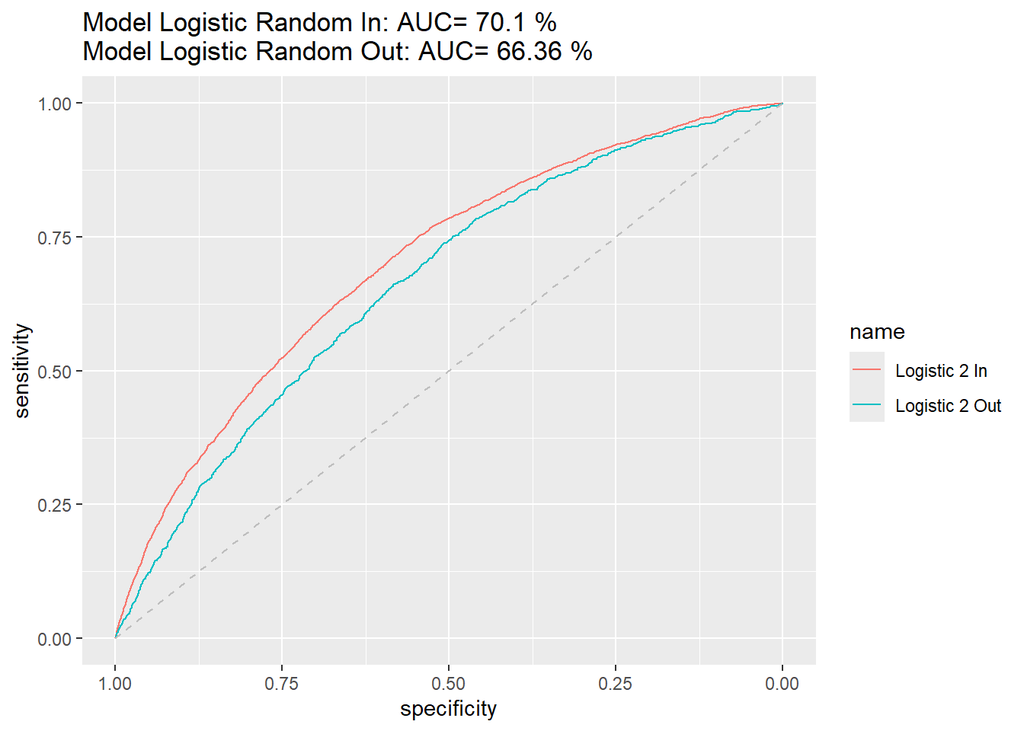

```r
# Make in-sample predictions on the training set
p_random_in <- predict(logistic_model, training_random, type = "response")

# Generate the ROC curve for in-sample predictions
ROC_logistic_random_in <- roc(training_random$default, p_random_in)
# Calculate the AUC for the in-sample ROC curve
AUC_logistic_random_in <- ROC_logistic_random_in$auc

# Make out-of-sample predictions on the testing set
p_random_out <- predict(logistic_model, testing_random, type = "response")

# Generate the ROC curve for out-of-sample predictions
ROC_logistic_random_out <- roc(testing_random$default, p_random_out)
# Calculate the AUC for the out-of-sample ROC curve
AUC_logistic_random_out <- ROC_logistic_random_out$auc

# Plot both ROC curves (in-sample and out-of-sample) on the same plot
ggroc(list("Logistic 2 In" = ROC_logistic_random_in, "Logistic 2 Out" = ROC_logistic_random_out)) +

  # Add a title showing the AUC values for both curves
  ggtitle(
    paste(
      "Model Logistic Random In: AUC=", round(AUC_logistic_random_in * 100, digits = 2), "%",
      "\nModel Logistic Random Out: AUC=", round(AUC_logistic_random_out * 100, digits = 2), "%"
    )
  ) +

  # Add a diagonal dashed line (random classifier baseline)
  geom_segment(aes(x = 1, xend = 0, y = 0, yend = 1), color = "grey", linetype = "dashed")
```

Provide comments here: The difference between AUC sample in and sample out has changed negatively. The AUC for training is greater than AUC sample out but there is no significant over-fitting. The reduce in AUC for out sample could be due to the noise from random variables.

## 4.2 Selecting loans to invest in using the model Logistic 2. **(Q11)**

Before we look for a better model than logistic 2 let’s see how we can use this model to select loans to invest. Let’s make the simplistic assumption that every loan generates $15 profit if it is paid off and $75 loss if it is charged off for an investor. Let’s use a cut-off value to determine which loans to invest in, that is, if the predicted probability of default for a loan is below this value then we invest in that loan and not if it is above.

To do this we split the data in three parts: training, validation, and testing. Feel free to experiment with different seeds but please use the seeds provided below for your submission.

```r
# splitting the data into training and testing
set.seed(24)
train_test_split <- initial_split(lc_clean, prop = 0.6)
training <- training(train_test_split) #60% of the data is set aside for training
remaining <- testing(train_test_split) #40% of the data is set aside for validation & testing
set.seed(2024)
train_test_split <- initial_split(remaining, prop = 0.5)
validation<-training(train_test_split) #50% of the remaining data (20% of total data) will be used for validation
testing<-testing(train_test_split) #50% of the remaining data (20% of total data) will be used for testing
```

> **Q11**. Train logistic 2 on the training set above. Use the trained model to determine the optimal cut-off threshold based on the validation test. What is the optimal cutoff threshold? How much profit does it generate? Using the testing set, what is the profit per loan associated with the cutoff?

Insert your code here:

```r
#estimate the model on the training set
# Train a logistic regression model (logistic2) to predict 'default' using specified predictors
logistic2 <- glm(default ~ annual_inc + term + grade + loan_amnt, family = "binomial", data = training)
```

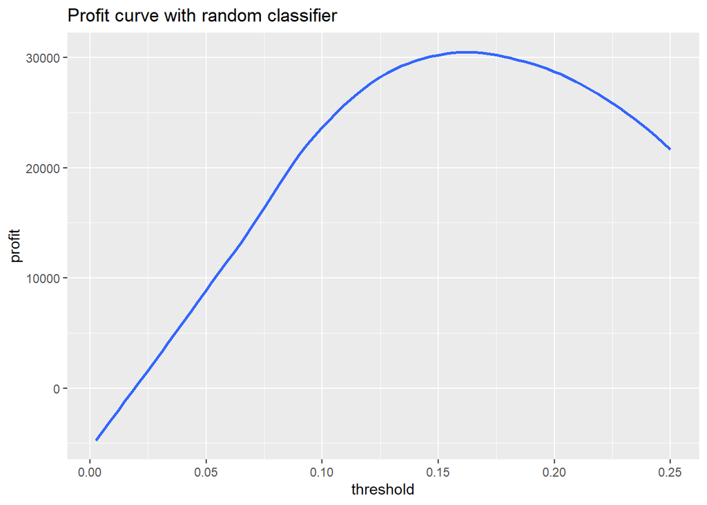

```r
# Make predictions on the validation set using the logistic2 model
# 'type = "response"' returns predicted probabilities of default
p_val <- predict(logistic2, validation, type = "response")

# Define profit and loss per classification outcome
unit_profit <- 15   # profit per correctly predicted non-default (TN)
unit_loss <- 75     # loss per incorrectly predicted default (FP)

# Initialize vectors to store profit and threshold values
profit <- 0           # profit at each threshold
threshold <- 0        # threshold values (from 0.0025 to 0.25, incremented by 0.0025)

# Loop over 100 threshold values from 0.0025 to 0.25 in steps of 0.0025
for(i in 1:100) {
  # Calculate the current threshold value
  threshold[i] <- i / 400

  # Classify predictions as 1 (default) or 0 (non-default) based on the current threshold
  classify_one_or_zero <- ifelse(p_val > threshold[i], 1, 0)

  # Generate a confusion matrix to evaluate predictions against actual outcomes
  cm <- confusionMatrix(as.factor(classify_one_or_zero), as.factor(validation$default), positive = "1")

  # Calculate profit: true negatives (cm$table[1,1]) yield profit; false positives (cm$table[1,2]) incur loss
  profit[i] <- cm$table[1, 1] * unit_profit - cm$table[1, 2] * unit_loss
}

# Plot the profit curve over different threshold values
ggplot(as.data.frame(threshold), aes(x = threshold, y = profit)) +
  geom_smooth(method = 'loess', se = 0) +
  labs(title = "Profit curve with random classifier")
```

```r
# Find the maximum profit and corresponding threshold
profit_max <- max(profit)
threshold_max <- threshold[which.max(profit)] * 100

# Print the maximum profit and the optimal threshold as percentages
print(profit_max)
```

```
## [1] 31050
```

```r
print(threshold_max)
```

```
## [1] 16.5
```

```r
# Generate predicted probabilities of default for the testing set using the logistic2 model
p_test <- predict(logistic2, testing, type = "response")

# Classify predictions as 1 (default) or 0 (non-default) based on a threshold of 16.5%
classify_one_or_zero_test <- ifelse(p_test > 0.165, 1, 0)

# Create a confusion matrix comparing predictions with actual default values in the testing set
cm_test <- confusionMatrix(as.factor(classify_one_or_zero_test), as.factor(testing$default), positive = "1")

# Calculate profit on the testing set:
# Profit = (True Negatives * unit profit) - (False Positives * unit loss)
profit_test <- cm_test$table[1, 1] * unit_profit - cm_test$table[1, 2] * unit_loss

# Print the profit obtained on the testing set
print(profit_test)
```

```
## [1] 33225
```

# 5 More realistic revenue model **(Q12-Q18)**

Let’s build a more realistic profit and loss model. Each loan has different terms (e.g., different interest rate and different duration) and therefore a different return if fully paid. For example, a 36 month loan of $5000 with instalment of $163 per month would generate a return of `163*36/5000-1=17.36%` if there was no default. Let’s assume that it would generate a loss of -60% if there was a default (the loss is not 100% because the loan may not default immediately and/or the lending club may be able to recover part of the loan).

> **Q12**. Under these assumptions, how much return would you get if you invested $1 in each loan in the validation set? Express your answer as a % return.

Insert your code here:

```r
#add code here
# Classify observations in the validation set as 1 (default) or 0 (non-default) using a 16.5% threshold
classify_mt <- ifelse(p_val > 0.165, 1, 0)

# Initialize counters for missed non-defaults and total return on investment (ROI)
misses <- 0    # Count of defaults that were incorrectly classified as non-defaults
ROI <- 0       # Total ROI based on classifications
counter <- 1   # Initialize a counter for row indexing in the loop

# Loop through each classification result in 'classify_mt'
for (i in classify_mt) {

  # Check if the classification is 0 (non-default) and the actual outcome in the validation set is also 0
  if (i == 0 & validation[counter,]$default == 0) {

    # If correct non-default prediction, calculate return based on loan terms
    # ROI is increased by ((term * installment amount / loan amount) - 1), which represents loan return
    ROI <- ROI + ((((validation[counter,]$term_months * validation[counter,]$installment) / validation[counter,]$loan_amnt) - 1))

  # Check if classification is 0 (non-default) but actual outcome is 1 (default)
  } else if (i == 0 & validation[counter,]$default == 1) {

    # If incorrect non-default prediction, apply a fixed loss of 60% of the loan amount
    ROI <- ROI - 0.6

    # Increase the 'misses' counter to record the misclassification
    misses <- misses + 1
  }

  # Move to the next row in the validation set
  counter <- counter + 1
}

# Calculate the average ROI as a percentage
avg_ROI <- (ROI / nrow(validation)) * 100

# Print the average ROI as a percentage
print(avg_ROI)
```

```
## [1] 6.586861
```

> **Q13**. Take the exact same setting as in Q10; however, assume that each time there is default we further incur a fixed cost of $ $C$ in addition to the 60% loss. What is the maximum amount of $C$ which would still give a positive mean return in the previous setting (*i.e.*, investing $ 1 in each loan).

Insert your code here:

```r
#add code here
# Define a function 'avg_return' that calculates the average return on investment (ROI)
# given a specific cost added to the default scenario
avg_return <- function(cost) {

  # For each loan in the validation set, calculate 'loan_return' based on whether there was a default
  # - If no default (default == "0"), return = (installment * term months / loan amount) - 1, indicating profit
  # - If default (default == "1"), return = -0.6 - cost, where -0.6 is the standard loss and 'cost' is an additional fixed cost
  validation <- validation %>%
    mutate(loan_return = ifelse(default == "0", installment * term_months / loan_amnt - 1, -0.6 - cost))

  # Calculate the average ROI (avg_ROI) across all loans in the validation set
  avg_ROI <- mean(validation$loan_return)

  # Return the average ROI value
  return(avg_ROI)
}

# Define a range of cost values from 0 to 1 in increments of 0.01 to evaluate
cost_range <- seq(0, 1, 0.01)

# Apply the 'avg_return' function across each cost in 'cost_range' using 'sapply'
# - This produces a vector 'avg_returns_values' of average ROI values for each cost in the range
avg_returns_values <- sapply(cost_range, avg_return)

# Identify the maximum cost for which the average ROI is still positive
max_cost <- max(cost_range[avg_returns_values > 0])

# Print the maximum allowable cost that maintains a positive average ROI
print(max_cost)
```

```
## [1] 0.74
```

Insert comments here: A fixed cost of **$0.74** for every missed prediction of default would still return a positive mean ROI. Further fixed cost, would result a negative ROI.

From here onward, drop the assumption of an additional fixed cost as introduced in Q11 and take the revenue model introduced in Q10. Unfortunately, we cannot use the realized return to select loans to invest (as at the time we make the investment decision we do not know which loan will default). Instead, we can calculate an expected return using the estimated probabilities of default – expected return = return if not default * (1-prob(default)) + return if default * prob(default).

> **Q14**. Calculate the expected return of the loans in the validation set using the `logistic2` model trained in the training set. Can you use the expected return metric to select a portfolio of the $n$ most promising loans to invest in ($n$ is an integer number)? How does the **realized** return vary as you change $n$? What is the profit for $n=700$?

Insert your code here:

```r
#add code here

validation <- validation %>%
  mutate(exp_return = (installment*term_months/loan_amnt - 1)*(1-p_val) + (-0.6 * p_val))

validation <- validation %>%
  mutate(prob_default = p_val)

validation <- validation[order(-validation$exp_return), ]
```

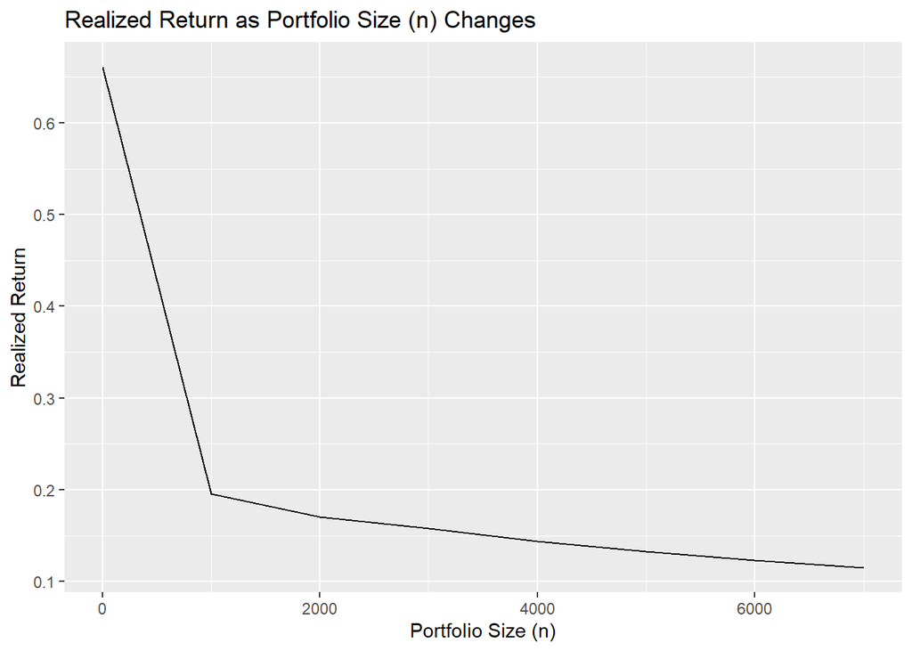

```r
n_values <- seq(1, nrow(validation), by = 1000) # Change in increments of 10 for efficiency
realized_returns <- numeric(length(n_values))

# Calculate realized return for the top n loans
for (j in 1:length(n_values)) {
  n <- n_values[j]
  ROI <- 0

  for (i in 1:n) {
    if (validation[i, ]$default == 0 & validation[i, ]$prob_default <= 16.5) {
      # Non-default: Calculate ROI based on actual return
      ROI <- ROI + ((validation[i, ]$term_months * validation[i, ]$installment) / validation[i, ]$loan_amnt - 1)
    } else if (validation[i, ]$default == 1 & validation[i, ]$prob_default <= 16.5){
      # Default: Apply the -60% loss
      ROI <- ROI - 0.6
    }
  }

  # Store the average ROI for the top n loans
  realized_returns[j] <- ROI / n
}

df <- data.frame(n = n_values, realized_return = realized_returns)
ggplot(df, aes(x = n, y = realized_return)) +
  geom_line() +
  labs(title = "Realized Return as Portfolio Size (n) Changes",
       x = "Portfolio Size (n)",
       y = "Realized Return")
```

```r
profit_700 = 0
for (i in 1:700) {
  if (validation[i, ]$default == 0) {
    profit_700 <- profit_700 + ((validation[i, ]$term_months * validation[i, ]$installment) / validation[i, ]$loan_amnt - 1)
  } else{
    profit_700 <- profit_700 - 0.6
  }
}

# Print the profit for n=700
print(profit_700)
```

```
## [1] 147.1138
```

> **Q15**. For $n=700$, how sensitive is your answer to the assumption that if a loan defaults you lose 60% of the value? To answer this question assess how the realized return of the 700 loans chosen in your portfolio change if the loss proportion varies from 30%-90%?

```r
#add code here
calculate_profit_per_loss <- function(loss_rate) {
  profit = 0
  for (i in 1:700) {
    if (validation[i, ]$default == 0 & validation[i, ]$prob_default <= 16.5) {
      profit <- profit + ((validation[i, ]$term_months * validation[i, ]$installment) / validation[i, ]$loan_amnt - 1)
    } else if (validation[i, ]$default == 1 & validation[i, ]$prob_default <= 16.5) {
      profit <- profit - loss_rate
    }
  }

  return(profit)
}

loss_range <- seq(0.3, 0.9, 0.1)
profit_per_loss_values <- sapply(loss_range, calculate_profit_per_loss)


loss_vs_profit <- tibble(
  loss_rate = seq(0.3, 0.9, 0.1),
  profit = round(profit_per_loss_values, 2)
)

print(loss_vs_profit)
```

```
## # A tibble: 7 × 2
##   loss_rate profit
##       <dbl>  <dbl>
## 1       0.3  200.
## 2       0.4  183.
## 3       0.5  165.
## 4       0.6  147.
## 5       0.7  129.
## 6       0.8  112.
## 7       0.9   94.0
```

Insert your comments here: The profit reduces, as the loss percentage increases. Hence, the profit is sensitive and inversely related to loss.

> **Q16**. Experiment with different models using more features, interactions, and non-linear transformations. You may also want to try to estimate models using regularization (e.g., LASSO regression). Feel free to use data from other sources but make sure your model does not use information that would not be available at the time the loan is extended (e.g., for a 4-year loan given in January 2008, you can’t use macro-economic indicators for 2008 or 2009 to predict whether the loan will default). Present below your best model ONLY and explain why you have chosen it (at the very least comment on AUC of your model against other models, e.g. `logistic2.` Even better if you can compare your new model against logistic 2 on the realized return of 700 loans chosen out-of-sample from a data set of similar size to the validation set above.)

Insert your code here:

```r
# Convert columns to factors and create a binary default character variable
lc_clean <- lc_clean %>%
  mutate(
    def_chr = as.factor(ifelse(default == "1", "D", "P")),  # "D" for default, "P" for paid
    term = factor(term),                                     # Convert 'term' to a factor
    grade = factor(grade),                                   # Convert 'grade' to a factor
    home_ownership = factor(home_ownership),                 # Convert 'home_ownership' to a factor
    emp_length = factor(emp_length)                          # Convert 'emp_length' to a factor
  )

# Create additional feature columns for modeling
lc_clean <- lc_clean %>%
  mutate(
    income_loan_ratio = annual_inc / loan_amnt,              # Calculate income-to-loan ratio
    log_inc = log(annual_inc + 1),                           # Log-transform of annual income
    term_grade_intr = as.numeric(term) * as.numeric(grade),  # Interaction term between 'term' and 'grade'
    inc_grade_intr = annual_inc * as.numeric(grade)          # Interaction term between income and 'grade'
  )

# Stratified random sampling based on loan 'grade'
set.seed(121)
train_indices <- createDataPartition(lc_clean$grade, p = 0.7, list = FALSE)  # 70% for training
training <- lc_clean[train_indices, ]  # Training set
testing <- lc_clean[-train_indices, ]

# Define formula for the logistic model
formula <- def_chr ~ annual_inc + loan_amnt + income_loan_ratio + log_inc + term + grade + emp_length + inc_grade_intr + term_grade_intr

# Create model matrix for training data and extract target variable
X_train <- model.matrix(formula, data = training)[, -1]
y_train <- training$def_chr

# Fit LASSO model with cross-validation to select optimal lambda
lasso_model <- cv.glmnet(X_train, y_train, alpha = 1, family = "binomial")

# Extract the best lambda value based on minimum cross-validation error
min_lambda <- lasso_model$lambda.min

# Fit the LASSO model with the optimal lambda
model_lasso <- glmnet(X_train, y_train, family = "binomial", alpha = 1, lambda = min_lambda)

# Predict on the training set and calculate training AUC
train_pred <- predict(model_lasso, newx = X_train, type = "response")
train_roc <- roc(y_train, as.vector(train_pred))
train_auc <- auc(train_roc)

# Prepare testing data and calculate AUC for validation
X_val <- model.matrix(formula, data = testing)[, -1]
y_val <- as.numeric(as.character(testing$def_chr))
# Predict on the validation set and calculate validation AUC
val_pred <- predict(model_lasso, newx = X_val, type = "response")
val_roc <- roc(y_train, as.vector(train_pred))
val_auc <- auc(val_roc)

# Display AUC for training and testing sets
cat("AUC for LASSO model testing set:", val_auc, "\n")
```

[output not shown]

```r
cat("AUC for LASSO model training set:", train_auc, "\n")
```

```
## AUC for LASSO model training set: 0.6864864
```

> **Q17**. The file “Assessment Data_2024.csv” contains information on almost $1,800$ new loans. Use your best model (see previous question) to choose 240 loans to invest in. For this question assume that the loss proportion is 60%. Your grade on this question will be based on the actual performance of your choices.

```r
# Read the assessment data CSV file and create new features
lc_assessment <- read_csv("D:\\data_science_business\\assignment2\\Assessment Data_2024.csv") %>%
  mutate(
    term = as.factor(`term (months)`),                       # Convert 'term' to factor
    grade = as.factor(grade),                                # Convert 'grade' to factor
    home_ownership = factor(home_ownership),                 # Convert 'home_ownership' to factor
    emp_length = factor(emp_length),                         # Convert 'emp_length' to factor
    income_loan_ratio = annual_inc / loan_amnt,              # Calculate income-to-loan ratio
    log_inc = log(annual_inc + 1),                           # Apply log transformation to income
    term_grade_intr = as.numeric(term) * as.numeric(grade),  # Interaction term: 'term' * 'grade'
    inc_grade_intr = annual_inc * as.numeric(grade)          # Interaction term: income * 'grade'
  )
# Align factor levels in assessment data with training data for consistency
lc_assessment$term <- factor(lc_assessment$term, levels = levels(training$term))
lc_assessment$grade <- factor(lc_assessment$grade, levels = levels(training$grade))
lc_assessment$home_ownership <- factor(lc_assessment$home_ownership, levels = levels(training$home_ownership))
lc_assessment$emp_length <- factor(lc_assessment$emp_length, levels = levels(training$emp_length))

# Define the model formula for prediction without the response variable
predict_formula <- ~ annual_inc + loan_amnt + income_loan_ratio + log_inc + term + grade + emp_length + inc_grade_intr + term_grade_intr

# Create a model matrix for assessment data to match the structure of training data
X_asmnt <- model.matrix(predict_formula, data = lc_assessment)[, -1]

# Identify missing columns in X_assessment and add them as zero columns for consistency
missing_cols <- setdiff(colnames(X_train), colnames(X_asmnt))
if (length(missing_cols) > 0) {
  X_asmnt <- cbind(X_asmnt, Matrix(0, nrow = nrow(X_asmnt), ncol = length(missing_cols)))
  colnames(X_asmnt)[(ncol(X_asmnt) - length(missing_cols) + 1):ncol(X_asmnt)] <- missing_cols
}

# Ensure column order in X_assessment matches that in X_train
X_asmnt <- X_asmnt[, colnames(X_train)]

# Predict default probabilities using the trained LASSO model
predict_probs <- predict(model_lasso, newx = X_asmnt, type = "response")

# Calculate expected returns for each loan in the assessment data
lc_assessment <- lc_assessment %>%
  mutate(
    predicted_prob = as.vector(predict_probs),               # Store predicted probabilities
    installment = as.numeric(installment),                   # Convert 'installment' to numeric
    term_months = as.numeric(`term (months)`),               # Convert 'term' to numeric
    loan_amnt = as.numeric(loan_amnt),                       # Convert 'loan_amnt' to numeric
    return_if_paid = (installment * term_months) / loan_amnt - 1, # Expected return if loan is paid in full
    return_if_default = -0.6,                                # Expected return if loan defaults
    expected_return = return_if_paid * (1 - predict_probs) + return_if_default * predict_probs # Calculate expected return
  )

# Select the top 240 loans based on expected return
selected_loans <- lc_assessment %>%
  arrange(desc(expected_return)) %>%                         # Sort loans by expected return
  slice_head(n = 240) %>%                                    # Select top 240 loans
  mutate(roopa_yashaswini = 1) %>%                           # Label selected loans with 1
  select(`Loan number`, roopa_yashaswini)

# Label remaining (non-selected) loans with 0
non_selected_loans <- lc_assessment %>%
  filter(!`Loan number` %in% selected_loans$`Loan number`) %>% # Filter non-selected loans
  mutate(roopa_yashaswini = 0) %>%                           # Label non-selected loans with 0
  select(`Loan number`, roopa_yashaswini)

# Combine selected and non-selected loans, keeping original order
final_selection <- bind_rows(selected_loans, non_selected_loans) %>%
  arrange(`Loan number`) %>%                                 # Arrange by loan number
  rename(loan_number = `Loan number`)                        # Rename column for output

# Save the final selection to a CSV file
write.csv(final_selection, "Roopa_Yashaswini.csv", row.names = FALSE)
```

The submitted output should be a csv file `firstname_lastname.csv` containing only two columns: column A should have the loan number. Column B should have your name on top and then the number 1 for loans you would like to invest in and number 0 otherwise. For example, if “Kamalini Ramdas” wanted to invest in loans 2 and 4 but not in loans 1, 3, or 5, her submission should be named `kamalini_ramdas.csv` and if opened in Excel should look like this:

[figure not shown]

Sample Submission

(If you can’t see the picture make sure you download it from canvas in your working directory.) **Please follow these instructions closely.** For example,

1. Do not change the order of the loans.
2. Do not submit a list of the loan numbers you would invest in.
3. Do not invest in more than 240 loans.
4. Make sure the loan numbers are in column A and the choices in column B, start in cell A1.
5. Don’t forget to add your name.

*Before you submit, open your file in EXCEL to make sure it looks like the sample above. Also check that the file size is not more that a few kilobytes. If it’s more you are doing something wrong.*

Add to the code below:

```r
lc_assessment<- read_csv("Assessment Data_2024.csv") %>%  #load the data
  clean_names() %>% # use janitor::clean_names()
  mutate(
    issue_d = mdy(issue_d),  # lubridate::mdy() to fix date format
    term = factor(term_months),     # turn 'term' into a categorical variable
    delinq_2yrs = factor(delinq_2yrs)) # turn 'delinq_2yrs' into a categorical variable
```

After you have submitted your report I will upload a screen cast that discusses the performance of your chosen portfolios. I will also use this screen cast to illustrate the “wisdom of the crowd” principle. So please make sure you watch it.

Please submit an html knitted version of your rmd file. Before you submit, please check that the file has knitted correctly and it is not too large (e.g., you are not printing the whole data set or all your investment choices!). Also, please submit on time – delayed submissions will be penalized according to the course policy.

> **Q18**. **(Optional)**

> At a high level, what we have done in this assignment is a two-step process: (1) building a prediction model for loan defaults and (2) making decisions on which loans to invest in.

> When we build our prediction model, our goal is to make accurate predictions on testing data (accuracy, sensitivity, specificity, AUC, AIC, etc.). When we make our investment decisions, our goal is to maximize profit (in our case, the average return of the selected loans in the testing data). Do you think a good prediction model always leads to a good investment decision? If this is not always the case, why or why not?

> Some loans offer higher returns than others. Are they equally important when we make our investment decisions? One argument is that we should care more about our prediction performance on high-return loans because we want to invest in non-defaulting, high-return loans. Try to modify your prediction model based on this idea, explain your model, and interpret its performance.